# Association rules

```r
library(tidyverse)
library(dplyr)
library(arules)
library(arulesViz)

data("Groceries")
summary(Groceries)
```

```
transactions as itemMatrix in sparse format with
 9835 rows (elements/itemsets/transactions) and
 169 columns (items) and a density of 0.02609146

most frequent items:
      whole milk other vegetables       rolls/buns             soda           yogurt          (Other)
            2513             1903             1809             1715             1372            34055

element (itemset/transaction) length distribution:
sizes
   1    2    3    4    5    6    7    8    9   10   11   12   13   14   15   16   17   18   19   20   21   22   23   24   26   27   28   29
2159 1643 1299 1005  855  645  545  438  350  246  182  117   78   77   55   46   29   14   14    9   11    4    6    1    1    1    1    3
  32
   1

   Min. 1st Qu.  Median    Mean 3rd Qu.    Max.
  1.000   2.000   3.000   4.409   6.000  32.000

includes extended item information - examples:
```

|  | labels | level2 | level1 |
| --- | --- | --- | --- |
| 1 | frankfurter | sausage | meat and sausage |
| 2 | sausage | sausage | meat and sausage |
| 3 | liver loaf | sausage | meat and sausage |

Groceries is of class transactions (sparse matrix). The data consists of 9835 rows, and 169 columns.

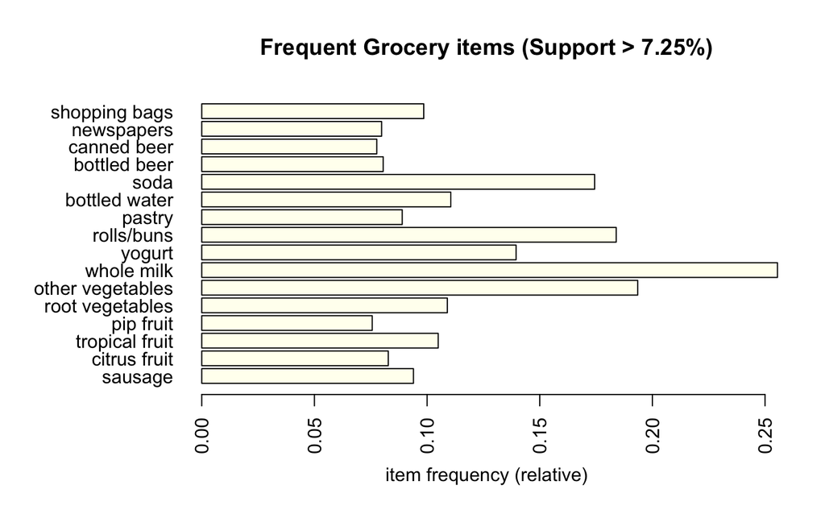

```r
itemFrequencyPlot(Groceries,
                  support=0.0725,
                  horiz = TRUE,
                  col = "ivory",
                  main = "Frequent Grocery items (Support > 7.25%)")
```

The bar plot above displays frequent items, that meet the support value. The minimum support threshold is set at 7.25%, meaning that only items appearing in at least 7.25% of all transactions are considered frequent. As a result we got 16 frequent products.

```r
rules <- apriori (Groceries, parameter = list(supp = 0.001, conf = 0.5))
```

```
Apriori

Parameter specification:
```

|  | confidence | minval | smax | arem | aval | originalSupport | maxtime | support | minlen | maxlen | target | ext |
| --- | --- | --- | --- | --- | --- | --- | --- | --- | --- | --- | --- | --- |
|  | 0.5 | 0.1 | 1 | none | FALSE | TRUE | 5 | 0.001 | 1 | 10 | rules | TRUE |

```
Algorithmic control:
```

|  | filter | tree | heap | memopt | load | sort | verbose |
| --- | --- | --- | --- | --- | --- | --- | --- |
|  | 0.1 | TRUE | TRUE | FALSE | TRUE | 2 | TRUE |

```
Absolute minimum support count: 9

set item appearances ...[0 item(s)] done [0.00s].
set transactions ...[169 item(s), 9835 transaction(s)] done [0.00s].
sorting and recoding items ... [157 item(s)] done [0.00s].
creating transaction tree ... done [0.00s].
checking subsets of size 1 2 3 4 5 6 done [0.01s].
writing ... [5668 rule(s)] done [0.00s].
creating S4 object  ... done [0.00s].
```

```r
# summary(rules)
# inspect(rules[1:5])
# itemLabels(Groceries)
lhs_rules <- subset(rules, lhs %in% "cream cheese ")
rhs_rules <- subset(rules, rhs %in% "cream cheese ")

summary(lhs_rules)
```

```
set of 233 rules

rule length distribution (lhs + rhs):sizes
  3   4   5
 59 137  37

   Min. 1st Qu.  Median    Mean 3rd Qu.    Max.
  3.000   3.000   4.000   3.906   4.000   5.000

summary of quality measures:
    support           confidence        coverage             lift            count
 Min.   :0.001017   Min.   :0.5000   Min.   :0.001118   Min.   : 1.957   Min.   :10.00
 1st Qu.:0.001118   1st Qu.:0.5556   1st Qu.:0.001729   1st Qu.: 2.642   1st Qu.:11.00
 Median :0.001220   Median :0.6154   Median :0.002034   Median : 3.138   Median :12.00
 Mean   :0.001536   Mean   :0.6480   Mean   :0.002494   Mean   : 3.563   Mean   :15.11
 3rd Qu.:0.001729   3rd Qu.:0.7143   3rd Qu.:0.002847   3rd Qu.: 3.982   3rd Qu.:17.00
 Max.   :0.006609   Max.   :1.0000   Max.   :0.012405   Max.   :11.041   Max.   :65.00

mining info:
```

|  | data | ntransactions | support | confidence | call |
| --- | --- | --- | --- | --- | --- |
|  | Groceries | 9835 | 0.001 | 0.5 | apriori(data = Groceries, parameter = list(supp = 0.001, conf = 0.5)) |

```r
summary(rhs_rules)
```

```
set of 1 rules

rule length distribution (lhs + rhs):sizes
5
1

   Min. 1st Qu.  Median    Mean 3rd Qu.    Max.
      5       5       5       5       5       5

summary of quality measures:
    support           confidence        coverage             lift           count
 Min.   :0.001017   Min.   :0.5882   Min.   :0.001729   Min.   :14.83   Min.   :10
 1st Qu.:0.001017   1st Qu.:0.5882   1st Qu.:0.001729   1st Qu.:14.83   1st Qu.:10
 Median :0.001017   Median :0.5882   Median :0.001729   Median :14.83   Median :10
 Mean   :0.001017   Mean   :0.5882   Mean   :0.001729   Mean   :14.83   Mean   :10
 3rd Qu.:0.001017   3rd Qu.:0.5882   3rd Qu.:0.001729   3rd Qu.:14.83   3rd Qu.:10
 Max.   :0.001017   Max.   :0.5882   Max.   :0.001729   Max.   :14.83   Max.   :10

mining info:
```

|  | data | ntransactions | support | confidence | call |
| --- | --- | --- | --- | --- | --- |
|  | Groceries | 9835 | 0.001 | 0.5 | apriori(data = Groceries, parameter = list(supp = 0.001, conf = 0.5)) |

There is 233 rules that contain my product - cream cheese - on the left hand side. 59 rules involve three product subset, 137 four product subset, and 37 five product subset. And we get only 1 rule with cream cheese on right hand side, which is in the subset of five products. Indicating that cream cheese appears in combination with other products.

```r
inspect(sort(rhs_rules, by="lift"))
```

|  | lhs |  | rhs | support | confidence | coverage | lift | count |
| --- | --- | --- | --- | --- | --- | --- | --- | --- |
| [1] | {other vegetables, curd, yogurt, whipped/sour cream} | => | {cream cheese } | 0.001016777 | 0.5882353 | 0.001728521 | 14.83409 | 10 |

Let’s look at the first rule: If a person buys other vegetables, curd, yogurt, and whipped/sour cream this person 14.83 times more likely to buy cream cheese than a random customer in store. The support number is 0.001, meaning that 0.1% of all transactions studied had exact same item sets. Confidence is 0.59 => If someone buys other vegetables, curd, yogurt, and whipped/sour cream, there’s a 59% chance that they also buy cream cheese. Coverage number gives an idea how often the rule can be applied, in this case it equals to 0.002. This rule applies to 0.2% of all transactions in the dataset.

```r
inspect(sort(lhs_rules, by="lift")[2])
```

|  | lhs |  | rhs | support | confidence | coverage | lift | count |
| --- | --- | --- | --- | --- | --- | --- | --- | --- |
| [1] | {citrus fruit, other vegetables, whole milk, cream cheese } | => | {domestic eggs} | 0.001118454 | 0.5789474 | 0.001931876 | 9.124916 | 11 |

The next rule: If a person buys citrus fruit, other vegetables, whole milk, and cream cheese he/she is 9.12 times more likely to buy domestic eggs than a random purchaser in store. The support number is 0.001, this rule applies to only 0.1% of all transactions. This rule also have high confidence, saying that if customer buys citrus fruit, other vegetables, whole milk, and cream cheese, there is 58% chance they also buy domestic eggs. Coverage number is 0.002, meaning that this combination occurs in 0.2% of all transactions.

From these rules we see that certain sets of products are frequently purchased together. In combination they may be ingredients for salads, or other recipes. Cream cheese, in particular, is commonly used in baking and is a key ingredient in cheesecake. Despite that, cream cheese widely used for frosting, spreads, pasta sauces, dips, making it a versatile ingredient in a variety of dishes.

By identifying frequent combinations with cream cheese, the store can strategically place those items nearby—such as positioning cream cheese close to the vegetables/fruits section or within the dairy aisle for convenient access. Also, offering special discounts can boost sales. For example, if a customer buys cream cheese, offering a discount on berries or bagels can encourage bundled purchases. Additionally, analyzing product pairs allows the store to anticipate demand and adjust inventory accordingly, ensuring high-demand combinations are well-stocked ahead of time, especially during peak shopping seasons.

```r
inspect(lhs_rules[7:9])
```

|  | lhs |  | rhs | support | confidence | coverage | lift | count |
| --- | --- | --- | --- | --- | --- | --- | --- | --- |
| [1] | {cream cheese , frozen meals} | => | {whole milk} | 0.001016777 | 0.7142857 | 0.001423488 | 2.795464 | 10 |
| [2] | {hard cheese, cream cheese } | => | {other vegetables} | 0.001118454 | 0.5789474 | 0.001931876 | 2.992090 | 11 |
| [3] | {hard cheese, cream cheese } | => | {whole milk} | 0.001016777 | 0.5263158 | 0.001931876 | 2.059815 | 10 |

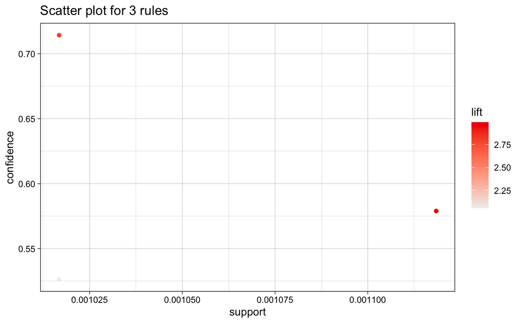

```r
plot(lhs_rules[7:9])
```

```r
plot(lhs_rules[7:9], method = "graph", engine="htmlwidget")
```

[interactive chart not shown]

Now the plot shows the relationship between rules as a graph. The central node represents cream cheese, which appears in all three rules, indicating that it is a key item in these associations. Hard cheese and whole milk appear in two rules each, showing that these items are associated with more than one combination of products. Frozen meals and other vegetables only appear in one rule each, which indicates that they are more specific to particular product combinations. Also the color differentiation in the plot corresponds to the lift value of each rule. The rule 3, which has lowest lift value in represented in light red. Meanwhile, Rules 1 and 2 are highlighted in bold red, suggesting that they have higher lift values and stronger associations between the items. Compared to previous plot, this visual shows elements of rules, allowing to quickly identify the central elements, and the relative strength of the rules. This plot also displays measures of rules (confidence, support) if we click on rule node. However, if we want to select strong rule the scatter plot is more useful because it clearly shows rules with higher support and confidence in a more clearer way. Therefore, the choice of plot depends on the purpose.